# STAT/MATH 495: Problem Set 09

Syed Abbas Shah

2017-11-07

# Collaboration

Please indicate who you collaborated with on this assignment:

No One

# Question 1: Run k-means

**Questions**:

1. Run KMC 10 times on `observations_1` and comment on the consistency of the results.
2. Speculate on the root cause of any consistency or inconsistency in the results.
3. Run KMC 10 times on `observations_2` and comment on the consistency of the results.
4. Speculate on the root cause of any consistency or inconsistency in the results.

**Answers**:

1. The results are fairly inconsistent. The cluster center changes location frequently, and the cluster assignments vary considerably. Sometimes, there are pretty dramatic variations such that the data go from being split horizontally to being split vertically. I’ve attached an example of one dramatic variation:

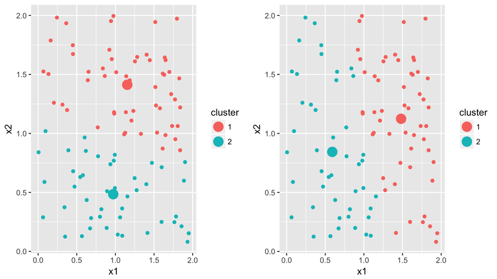

```r
grid.arrange(plot1,plot2, ncol=2)
```

As we can see, the cluster centers are in noticeably different positions, given the different assignment of clusters to data points. In one case, there is a horizontal partition, while in the second, there is a vertical one.

We are attempting to find two reasonably distinctive groups in the dataset. However, since the divisions between the points aren’t necessarily super clear and there is substantial overlap, it becomes hard to figure out whether the points in the middle are dissimilar to one another (and harder to figure out which cluster they belong to). Thus, cluster assignment in such unclear settings can be fairly arbitrary. The random cluster assignment at the start has an impact here, as the local optimum attained after multiple iterations of the algorithm (in each trial) will differ when the initial assignment changes (given the overlap/unclear distinction in the dataset). So the initial assignment in each run of the algorithm affects the identification of clusters, contributing to the inconsistency.

The results are pretty consistent. Running the code many times doesn’t change the general identification of two distinct clusters roughly separated across the diagonal $y = 2 - x$.

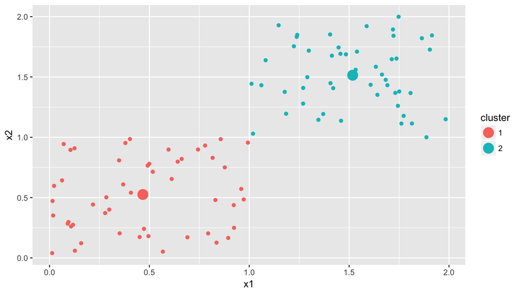

```r
plot3
```

The data are more cleanly partitioned in observations 2, with a diagonal line separating two discernible groups. Since we have, by setting K=2, told the algorithm to find two groups such that within group similarity and between group dissimilarity are high, assigning data points into clusters across the diagonal makes sense. The random assignment at the start doesn’t have a great impact here, as the local optimum attained after multiple iterations of the algorithm in each trial will eventually end up partitioning the two clusters in the same way. This is because, as noted earlier, the dataset has two noticeably partitioned groups.

# Bonus question: Code your own

Read ISLR page 388 Algorithm 10.1 and implement k-means clustering from scratch. Don’t worry about doing it for general $k$; keep it simple and do it for $k=2$ specifically. Apply it to `observations_2` from above.

General Algorithm:

1. Randomly Assign every observation to either cluster 1 or 2
2. Compute cluster center
3. Reassign every observation to either cluster 1 or 2 based on :
1. if distance b/w point and cluster 1 center is smaller than distance b/w point and cluster 2 center, assign point to cluster 1
2. otherwise assign point to cluster 2
4. Repeat until results don’t change i.e. until a local optimum is reached.

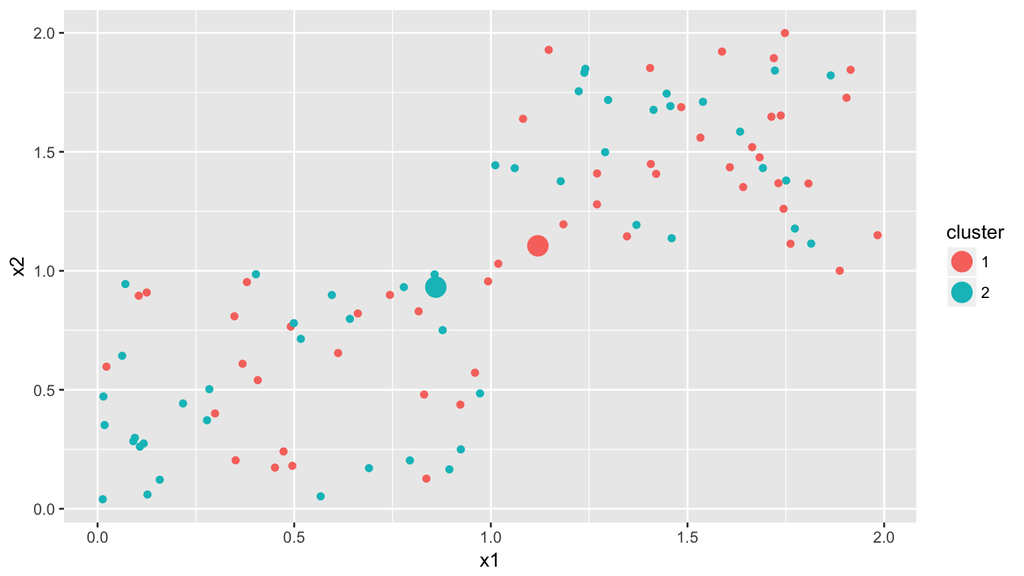

```r
observations<-observations_2

cluster<-sample(1:2, nrow(observations),replace=TRUE) #randomly assign clusters
initial<-data.frame(observations,cluster)
cent1<- initial %>%
  group_by(cluster) %>%
  summarize(mean(x1), mean (x2)) #get the mean values for each cluster
clustercenters<- cent1[2:3]

distance_matrix <- proxy::dist(x=observations, y=clustercenters) #Find distance b/w each point and both cluster centers

observations$cluster <- as.factor(cluster)

cluster_centers <- clustercenters %>%
  as_tibble() %>%
  mutate(cluster=as.factor(1:k))
cluster_centers<-cluster_centers %>%
  rename(x1=`mean(x1)`, x2 =`mean(x2)`)

plot4<-ggplot(NULL, aes(x=x1, y=x2, col=cluster)) +
geom_point(data=observations) +
 geom_point(data=cluster_centers, size=5)
plot4
```

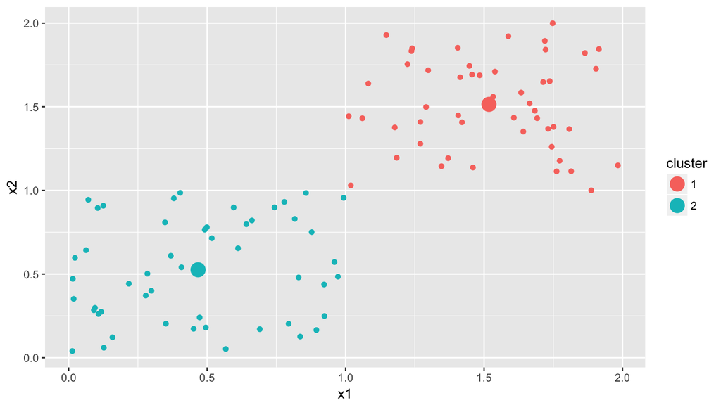

```r
cluster<-apply(distance_matrix, 1, which.min) #Find which cluster center each value is closest to.
observations<-data.frame(observations,cluster) #reassign clusters
observations <- observations[,-3]

cent2<- observations %>%
  group_by(cluster.1) %>%
  summarize(mean(x1), mean (x2)) #get the mean values for each cluster
clustercenters<- cent2[2:3]

observations$cluster <- as.factor(cluster)
cluster_centers <- clustercenters %>%
  as_tibble() %>%
  mutate(cluster=as.factor(1:k))
cluster_centers<-cluster_centers %>%
  rename(x1=`mean(x1)`, x2 =`mean(x2)`)

plot5<-ggplot(NULL, aes(x=x1, y=x2, col=cluster)) +
          geom_point(data=observations) +
        geom_point(data=cluster_centers, size=5)

plot5
```

We can see how, in just two iterations, the algorithm creates two reasonably distinct clusters in Observations_2.

## Hint

```r
# Hint:
library(proxy)
A <- data_frame(
  x1 = c(0, 0.5, 0.75, 1),
  x2 = c(0, 0.5, 0.75, 1)
)
B <- data_frame(
  x1 = c(1, 0),
  x2 = c(1, 0)
)
A
```

| x1 | x2 |
| --- | --- |
| 0.00 | 0.00 |
| 0.50 | 0.50 |
| 0.75 | 0.75 |
| 1.00 | 1.00 |

```r
B
```

| x1 | x2 |
| --- | --- |
| 1 | 1 |
| 0 | 0 |

```r
distance_matrix <- proxy::dist(x=A, y=B)
distance_matrix
```

```
##      [,1]      [,2]
## [1,] 1.4142136 0.0000000
## [2,] 0.7071068 0.7071068
## [3,] 0.3535534 1.0606602
## [4,] 0.0000000 1.4142136
```

```r
apply(distance_matrix, 1, which.min)
```

```
## [1] 2 1 1 1
```